# Improvised plots Grass DE

Lokesh

Lokesh Mano** • 25-feb-2023

# 1 Overall

## 1.1 Overview

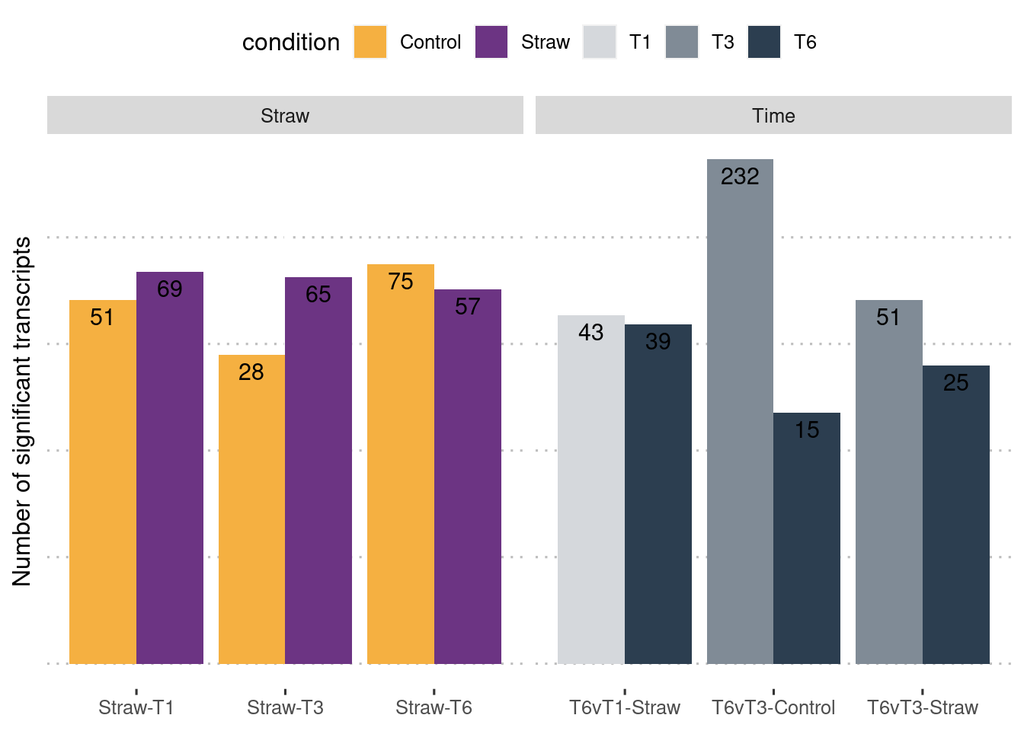

```r
library(ggplot2)
library(pheatmap)
library(ggpubr)
library(dplyr)
library(tidyverse)
library(ComplexHeatmap)
library(treemapify)

load("grass_de1.RData")
silva_hits <- read.table("Trinity_ass_200_vs_Sil132DB_all_NEW.hits")

gs_t1_annot <- de_gs_t1 %>%
  mutate(abs_fc = abs(log2FoldChange))%>%
  mutate(condition = ifelse(log2FoldChange > 0, "Straw", "Control")) %>%
  mutate(direction = ifelse(log2FoldChange > 0, "Positive", "Negative")) %>%
  rownames_to_column("Transcript") %>%
  left_join(tdb_annot %>% rownames_to_column("Transcript"), by = "Transcript") %>%
  left_join(taxa_annot %>% rownames_to_column("Transcript"), by = "Transcript")

gs_t1_annot$enz_class <- factor(gs_t1_annot$enz_class)
gs_t1_annot$enz_family <- factor(gs_t1_annot$enz_family)
#ggplot(gs_all_annot) + geom_bar(aes(x = condition, fill = enz_class), stat = "count")

ovr_plot_t1 <- gs_t1_annot %>%
  filter(!(is.na(enz_class) & (Transcript %in% silva_hits$V1))) %>%
  group_by(condition, direction) %>%
  summarise(num_sig= n(), sum_mean = sum(baseMean), sum_FC = sum(log2FoldChange))
ovr_plot_t1$test <- "Straw-T1"

gs_t3_annot <- de_gs_t3 %>%
  mutate(abs_fc = abs(log2FoldChange))%>%
  mutate(condition = ifelse(log2FoldChange > 0, "Straw", "Control")) %>%
  mutate(direction = ifelse(log2FoldChange > 0, "Positive", "Negative")) %>%
  rownames_to_column("Transcript") %>%
  left_join(tdb_annot %>% rownames_to_column("Transcript"), by = "Transcript") %>%
  left_join(taxa_annot %>% rownames_to_column("Transcript"), by = "Transcript")

ovr_plot_t3 <- gs_t3_annot %>%
  filter(!(is.na(enz_class) & (Transcript %in% silva_hits$V1))) %>%
  group_by(condition, direction) %>%
  summarise(num_sig= n(), sum_mean = sum(baseMean), sum_FC = sum(log2FoldChange))
ovr_plot_t3$test <- "Straw-T3"

gs_t6_annot <- de_gs_t6 %>%
  mutate(abs_fc = abs(log2FoldChange))%>%
  mutate(condition = ifelse(log2FoldChange > 0, "Straw", "Control")) %>%
  mutate(direction = ifelse(log2FoldChange > 0, "Positive", "Negative")) %>%
  rownames_to_column("Transcript") %>%
  left_join(tdb_annot %>% rownames_to_column("Transcript"), by = "Transcript") %>%
  left_join(taxa_annot %>% rownames_to_column("Transcript"), by = "Transcript")

ovr_plot_t6 <- gs_t6_annot %>%
  filter(!(is.na(enz_class) & (Transcript %in% silva_hits$V1))) %>%
  group_by(condition, direction) %>%
  summarise(num_sig= n(), sum_mean = sum(baseMean), sum_FC = sum(log2FoldChange))
ovr_plot_t6$test <- "Straw-T6"

gs_t6vt1_annot <- de_gs_t6vt1 %>%
  mutate(abs_fc = abs(log2FoldChange))%>%
  mutate(condition = ifelse(log2FoldChange > 0, "T6", "T1")) %>%
  mutate(direction = ifelse(log2FoldChange > 0, "Positive", "Negative")) %>%
  rownames_to_column("Transcript") %>%
  left_join(tdb_annot %>% rownames_to_column("Transcript"), by = "Transcript") %>%
  left_join(taxa_annot %>% rownames_to_column("Transcript"), by = "Transcript")

ovr_plot_t6vt1_gs <- gs_t6vt1_annot %>%
  filter(!(is.na(enz_class) & (Transcript %in% silva_hits$V1))) %>%
  group_by(condition, direction) %>%
  summarise(num_sig= n(), sum_mean = sum(baseMean), sum_FC = sum(log2FoldChange))
ovr_plot_t6vt1_gs$test <- "T6vT1-Straw"

gs_t6vt3_annot <- de_gs_t6vt3 %>%
  mutate(abs_fc = abs(log2FoldChange))%>%
  mutate(condition = ifelse(log2FoldChange > 0, "T6", "T3")) %>%
  mutate(direction = ifelse(log2FoldChange > 0, "Positive", "Negative")) %>%
  rownames_to_column("Transcript") %>%
  left_join(tdb_annot %>% rownames_to_column("Transcript"), by = "Transcript") %>%
  left_join(taxa_annot %>% rownames_to_column("Transcript"), by = "Transcript")

ovr_plot_t6vt3_gs <- gs_t6vt3_annot %>%
  filter(!(is.na(enz_class) & (Transcript %in% silva_hits$V1))) %>%
  group_by(condition, direction) %>%
  summarise(num_sig= n(), sum_mean = sum(baseMean), sum_FC = sum(log2FoldChange))
ovr_plot_t6vt3_gs$test <- "T6vT3-Straw"

gc_t6vt3_annot <- de_gc_t6vt3 %>%
  mutate(abs_fc = abs(log2FoldChange))%>%
  mutate(condition = ifelse(log2FoldChange > 0, "T6", "T3")) %>%
  mutate(direction = ifelse(log2FoldChange > 0, "Positive", "Negative")) %>%
  rownames_to_column("Transcript") %>%
  left_join(tdb_annot %>% rownames_to_column("Transcript"), by = "Transcript") %>%
  left_join(taxa_annot %>% rownames_to_column("Transcript"), by = "Transcript")

ovr_plot_t6vt3_gc <- gc_t6vt3_annot %>%
  filter(!(is.na(enz_class) & (Transcript %in% silva_hits$V1))) %>%
  group_by(condition, direction) %>%
  summarise(num_sig= n(), sum_mean = sum(baseMean), sum_FC = sum(log2FoldChange))
ovr_plot_t6vt3_gc$test <- "T6vT3-Control"

ovr_nsig_data <- rbind(ovr_plot_t1, ovr_plot_t3, ovr_plot_t6, ovr_plot_t6vt1_gs, ovr_plot_t6vt3_gs, ovr_plot_t6vt3_gc)

ovr_nsig_data <- ovr_nsig_data %>%
  mutate(Main_test = ifelse(any(grepl("Straw-", test)), "Straw", "Time"))

ovr_nsig_data$condition <- factor(ovr_nsig_data$condition, levels = c("Control", "Straw", "T1", "T3", "T6"))

ggplot(data = ovr_nsig_data) +
  geom_bar(aes(x = test, y = log10(num_sig), fill = condition),
           position = "dodge",stat = "identity") +
  geom_text(aes(test, log10(num_sig), label=num_sig, group = condition),
            vjust = 1.5, size=4, position = position_dodge(width = .9)) +
  facet_wrap(~Main_test, scales = "free_x") +
  scale_fill_manual(values = c("#F5B041", "#6C3483", "#D5D8DC", "#808B96", "#2C3E50")) +
  ylab("Number of significant transcripts") +
  theme_pubclean(base_size = 12) +
  theme(axis.text.y = element_blank(), axis.ticks.y = element_blank(), axis.title.x = element_blank())
```

## 1.2 Effect of Straw in T1

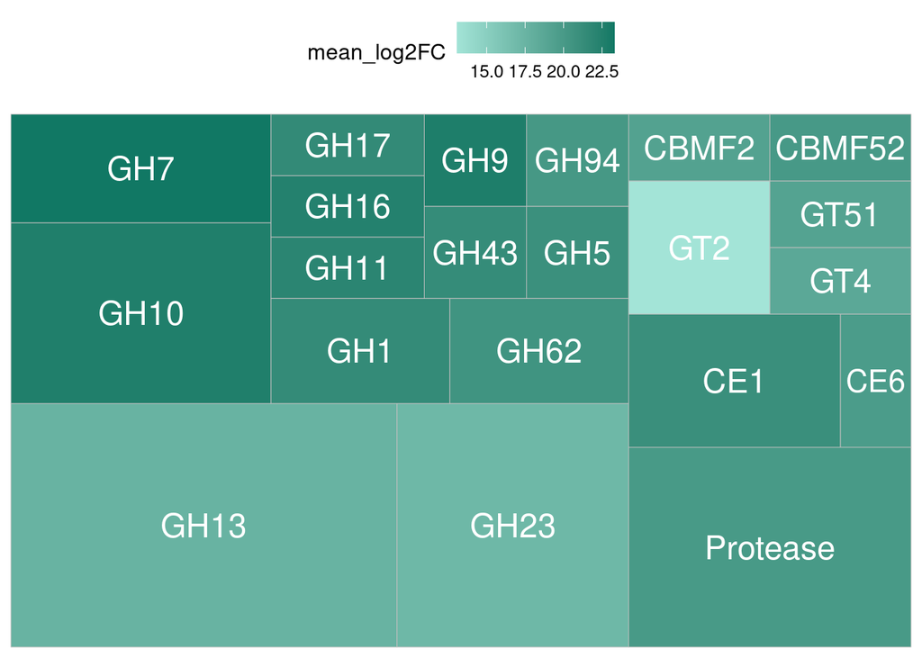

```r
gs_t1_tdb <- gs_t1 %>%
  filter(!(is.na(enz_class) & (Transcript %in% silva_hits$V1))) %>%
  filter(condition == "Straw") %>%
  group_by(enz_class, enz_family) %>%
  summarise(num_sig= n(), mean_log2FC = mean(abs(log2FoldChange))) %>%
  filter(!is.na(enz_class)) %>%
  arrange(desc(num_sig))

ggplot(data = gs_t1_tdb, aes(fill = mean_log2FC, area = num_sig, label= enz_family, subgroup=enz_class)) +
  geom_treemap() +
  geom_treemap_text(colour ="white", place = "centre") +
  theme_pubclean(base_size = 12) +
  scale_fill_gradient(low = "#A3E4D7", high = "#117864")
```

There were `110` transcripts in total that were significantly abundant in straw compared to control at T1! Out of which `51` had matchesto the TDB. The top CAZy families are listed below:

```r
#gs_all %>%
#  filter(condition == "Straw") %>%
#  dim()
#sum(gs_all_tdb$num_sig)
kable(head(gs_t1_tdb, 10))
```

| enz_class | enz_family | num_sig | mean_log2FC |
| --- | --- | --- | --- |
| GH | GH13 | 10 | 17.61853 |
| GH | GH23 | 6 | 17.14996 |
| Protease | Protease | 6 | 20.01067 |
| GH | GH10 | 5 | 22.63683 |
| CE | CE1 | 3 | 21.03440 |
| GH | GH7 | 3 | 23.31106 |
| GH | GH1 | 2 | 21.40495 |
| GH | GH62 | 2 | 20.58323 |
| GT | GT2 | 2 | 13.07196 |
| CBMF | CBMF2 | 1 | 19.18147 |

### 1.2.1 Heatmap of COG

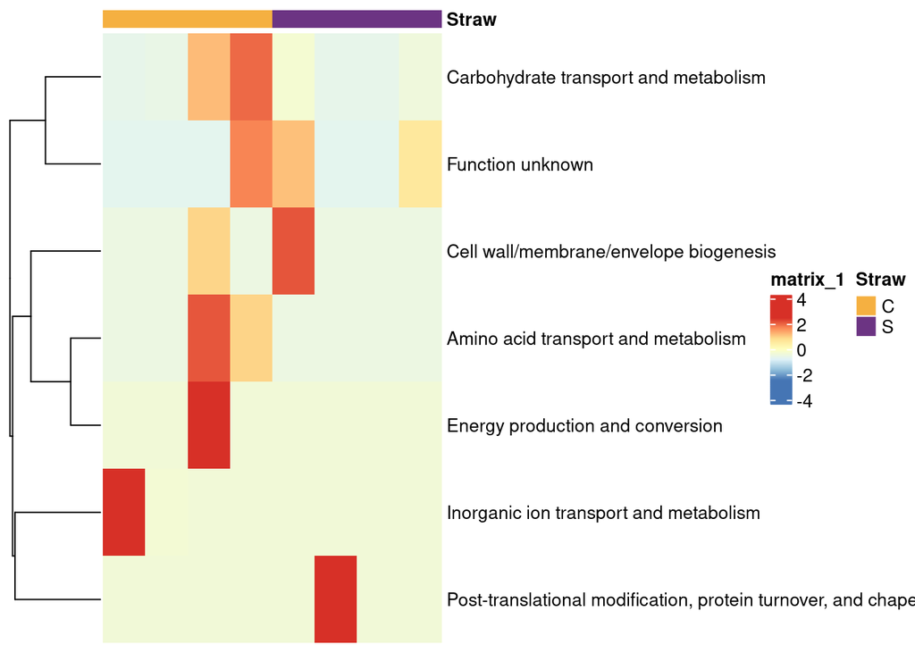

```r
tmm_mat <- read.table("SeqCap_gene.TMM.EXPR.matrix", header = T, row.names = 1, check.names = F)
sample_meta <-  read.table("All.samples", header = T, check.names = F)
sm_w_t1 <- sample_meta %>%
  filter(Time == "T1") %>%
  filter(Manag == "G") %>%
  arrange(Straw)


gs_t1_egg <- gs_t1 %>%
  filter(!(is.na(enz_class) & (Transcript %in% silva_hits$V1))) %>%
  filter(!is.na(cog_lev1))
gs_t1_tmm_egg <- tmm_mat[gs_t1_egg$Transcript, (colnames(tmm_mat) %in% sm_w_t1$Samples)]

gs_t1_tmm_egg_cog_lev2 <- gs_t1_tmm_egg %>%
  rownames_to_column(var = "Transcript") %>%
  gather(Sample_ID, count, -Transcript) %>%
  left_join(gs_t1_egg, by = "Transcript") %>%
  group_by(Sample_ID, cog_lev2) %>%
  summarise(sum_count = sum(count)) %>%
  spread(Sample_ID, sum_count)
temp <- gs_t1_tmm_egg_cog_lev2$cog_lev2
gs_t1_tmm_egg_cog_lev2$cog_lev2 <- NULL
row.names(gs_t1_tmm_egg_cog_lev2) <- temp

my_colour = list(
     Straw = c(C = "#F5B041", S = "#6C3483")
)

pheatmap(gs_t1_tmm_egg_cog_lev2, border_color=NA, annotation_col=sm_w_t1[,c("Straw"),drop=F],annotation_legend=T, scale = "row", annotation_colors = my_colour, show_colnames = F, cluster_cols = F)
```

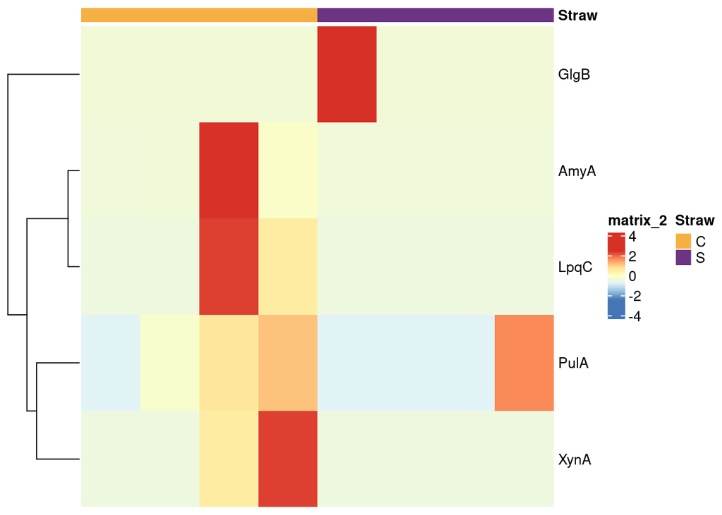

```r
gs_t1_tmm_egg_cog_enz <- gs_t1_tmm_egg %>%
  rownames_to_column(var = "Transcript") %>%
  gather(Sample_ID, count, -Transcript) %>%
  left_join(gs_t1_egg, by = "Transcript") %>%
  filter(cog_lev2 == "Carbohydrate transport and metabolism") %>%
  group_by(Sample_ID, cog_enzid) %>%
  summarise(sum_count = sum(count)) %>%
  spread(Sample_ID, sum_count)

temp <- gs_t1_tmm_egg_cog_enz$cog_enzid
gs_t1_tmm_egg_cog_enz$cog_enzid <- NULL
row.names(gs_t1_tmm_egg_cog_enz) <- temp

my_colour = list(
     Straw = c(C = "#F5B041", S = "#6C3483")
)

pheatmap(gs_t1_tmm_egg_cog_enz, border_color=NA, annotation_col=sm_w_t1[,c("Straw"),drop=F],annotation_legend=T, scale = "row", annotation_colors = my_colour, show_colnames = F, cluster_cols = F)
```

## 1.3 Effect of Straw in T3

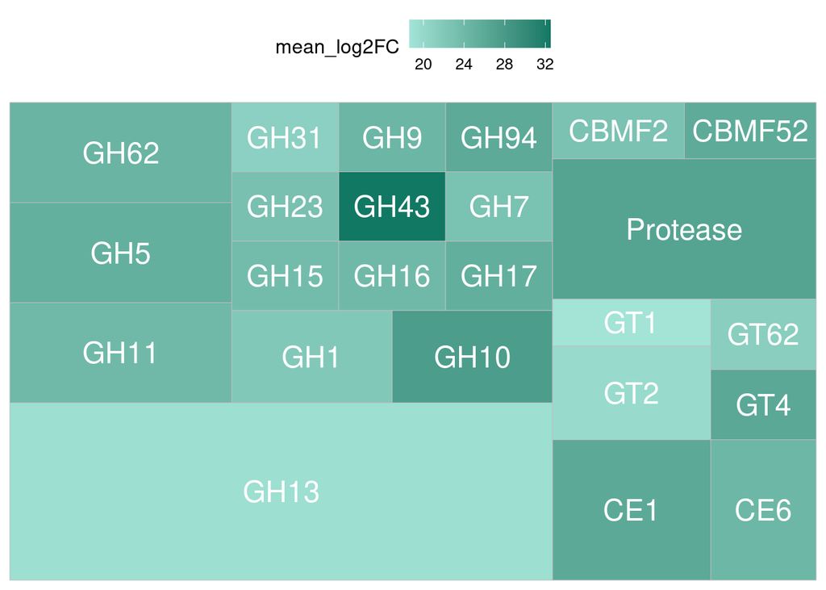

```r
gs_t3_tdb <- gs_t3 %>%
  filter(!(is.na(enz_class) & (Transcript %in% silva_hits$V1))) %>%
  filter(condition == "Straw") %>%
  group_by(enz_class, enz_family) %>%
  summarise(num_sig= n(), mean_log2FC = mean(abs(log2FoldChange))) %>%
  filter(!is.na(enz_class)) %>%
  arrange(desc(num_sig))

ggplot(data = gs_t3_tdb, aes(fill = mean_log2FC, area = num_sig, label= enz_family, subgroup=enz_class)) +
  geom_treemap() +
  geom_treemap_text(colour ="white", place = "centre") +
  theme_pubclean(base_size = 12) +
  scale_fill_gradient(low = "#A3E4D7", high = "#117864")
```

There were `97` transcripts in total that were significantly abundant in straw compared to control at t3! Out of which `52` had matches to the TDB. The top CAZy families are listed below:

```r
#gs_all %>%
#  filter(condition == "Straw") %>%
#  dim()
#sum(gs_all_tdb$num_sig)
kable(head(gs_t3_tdb, 10))
```

| enz_class | enz_family | num_sig | mean_log2FC |
| --- | --- | --- | --- |
| GH | GH13 | 13 | 19.25784 |
| Protease | Protease | 5 | 26.71359 |
| CE | CE1 | 3 | 25.97909 |
| GH | GH11 | 3 | 23.99645 |
| GH | GH5 | 3 | 25.15167 |
| GH | GH62 | 3 | 24.62611 |
| CE | CE6 | 2 | 24.26740 |
| GH | GH1 | 2 | 22.10417 |
| GH | GH10 | 2 | 27.61843 |
| GT | GT2 | 2 | 19.72532 |

### 1.3.1 Heatmap of COG

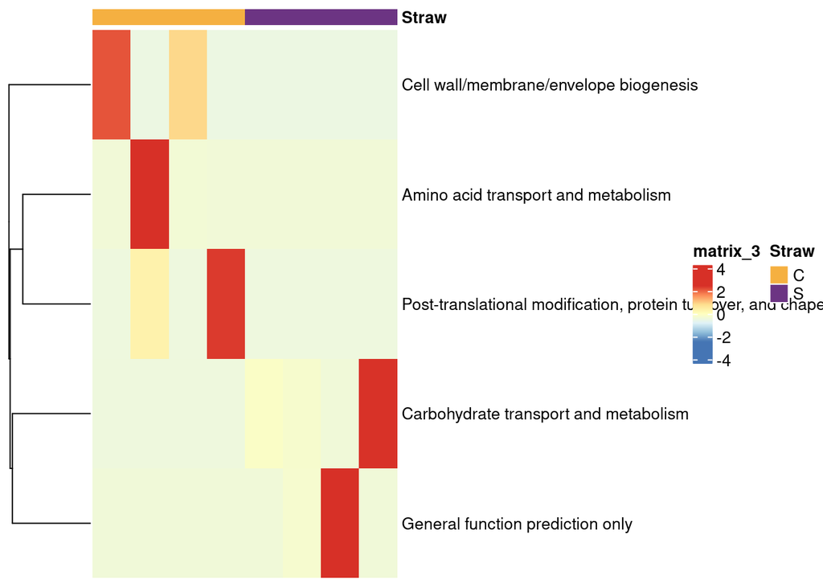

```r
#tmm_mat <- read.table("SeqCap_gene.TMM.EXPR.matrix", header = T, row.names = 1, check.names = F)
#sample_meta <-  read.table("All.samples", header = T, check.names = F)
sm_w_t3 <- sample_meta %>%
  filter(Time == "T3") %>%
  filter(Manag == "G") %>%
  arrange(Straw)


gs_t3_egg <- gs_t3 %>%
  filter(!(is.na(enz_class) & (Transcript %in% silva_hits$V1))) %>%
  filter(!is.na(cog_lev1))
gs_t3_tmm_egg <- tmm_mat[gs_t3_egg$Transcript, (colnames(tmm_mat) %in% sm_w_t3$Samples)]

gs_t3_tmm_egg_cog_lev2 <- gs_t3_tmm_egg %>%
  rownames_to_column(var = "Transcript") %>%
  gather(Sample_ID, count, -Transcript) %>%
  left_join(gs_t3_egg, by = "Transcript") %>%
  group_by(Sample_ID, cog_lev2) %>%
  summarise(sum_count = sum(count)) %>%
  spread(Sample_ID, sum_count)
temp <- gs_t3_tmm_egg_cog_lev2$cog_lev2
gs_t3_tmm_egg_cog_lev2$cog_lev2 <- NULL
row.names(gs_t3_tmm_egg_cog_lev2) <- temp

my_colour = list(
     Straw = c(C = "#F5B041", S = "#6C3483")
)

pheatmap(gs_t3_tmm_egg_cog_lev2, border_color=NA, annotation_col=sm_w_t3[,c("Straw"),drop=F],annotation_legend=T, scale = "row", annotation_colors = my_colour, show_colnames = F, cluster_cols = F)
```

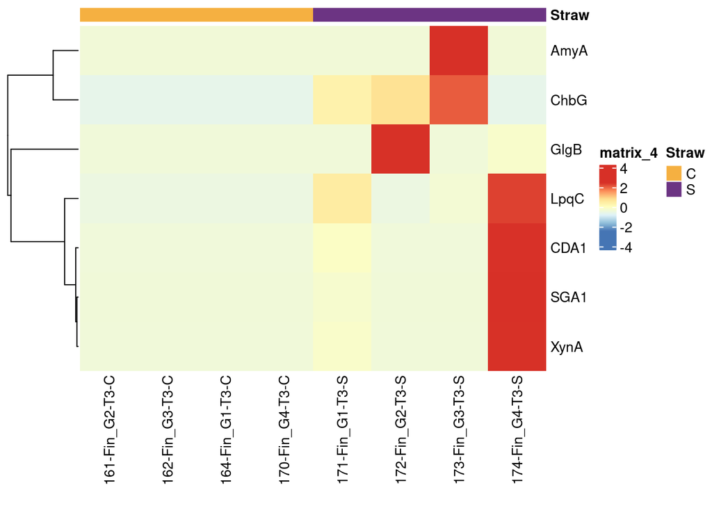

```r
gs_t3_tmm_egg_cog_enz <- gs_t3_tmm_egg %>%
  rownames_to_column(var = "Transcript") %>%
  gather(Sample_ID, count, -Transcript) %>%
  left_join(gs_t3_egg, by = "Transcript") %>%
  filter(cog_lev2 == "Carbohydrate transport and metabolism") %>%
  group_by(Sample_ID, cog_enzid) %>%
  summarise(sum_count = sum(count)) %>%
  spread(Sample_ID, sum_count)

temp <- gs_t3_tmm_egg_cog_enz$cog_enzid
gs_t3_tmm_egg_cog_enz$cog_enzid <- NULL
row.names(gs_t3_tmm_egg_cog_enz) <- temp

my_colour = list(
     Straw = c(C = "#F5B041", S = "#6C3483")
)

pheatmap(gs_t3_tmm_egg_cog_enz, border_color=NA, annotation_col=sm_w_t3[,c("Straw"),drop=F],annotation_legend=T, scale = "row", annotation_colors = my_colour, show_colnames = T, cluster_cols = F)
```

## 1.4 Effect of Straw in T6

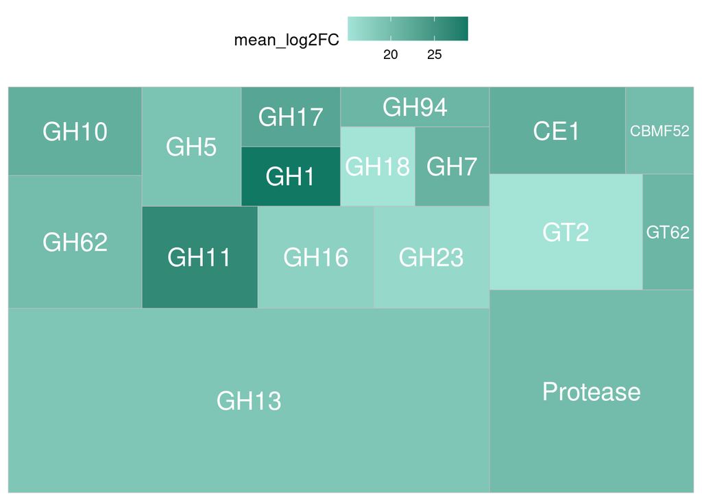

```r
gs_t6_tdb <- gs_t6 %>%
  filter(!(is.na(enz_class) & (Transcript %in% silva_hits$V1))) %>%
  filter(condition == "Straw") %>%
  group_by(enz_class, enz_family) %>%
  summarise(num_sig= n(), mean_log2FC = mean(abs(log2FoldChange))) %>%
  filter(!is.na(enz_class)) %>%
  arrange(desc(num_sig))

ggplot(data = gs_t6_tdb, aes(fill = mean_log2FC, area = num_sig, label= enz_family, subgroup=enz_class)) +
  geom_treemap() +
  geom_treemap_text(colour ="white", place = "centre") +
  theme_pubclean(base_size = 12) +
  scale_fill_gradient(low = "#A3E4D7", high = "#117864")
```

There were `66` transcripts in total that were significantly abundant in straw compared to control at t6! Out of which `47` had matches to the TDB. The top CAZy families are listed below:

```r
#gs_all %>%
#  filter(condition == "Straw") %>%
#  dim()
#sum(gs_all_tdb$num_sig)
kable(head(gs_t6_tdb, 10))
```

| enz_class | enz_family | num_sig | mean_log2FC |
| --- | --- | --- | --- |
| GH | GH13 | 15 | 18.80878 |
| Protease | Protease | 7 | 20.02753 |
| GH | GH62 | 3 | 19.98267 |
| GT | GT2 | 3 | 15.08460 |
| CE | CE1 | 2 | 21.79744 |
| GH | GH10 | 2 | 21.69455 |
| GH | GH11 | 2 | 26.54582 |
| GH | GH16 | 2 | 17.37963 |
| GH | GH23 | 2 | 16.40819 |
| GH | GH5 | 2 | 19.20338 |

### 1.4.1 Heatmap of COG

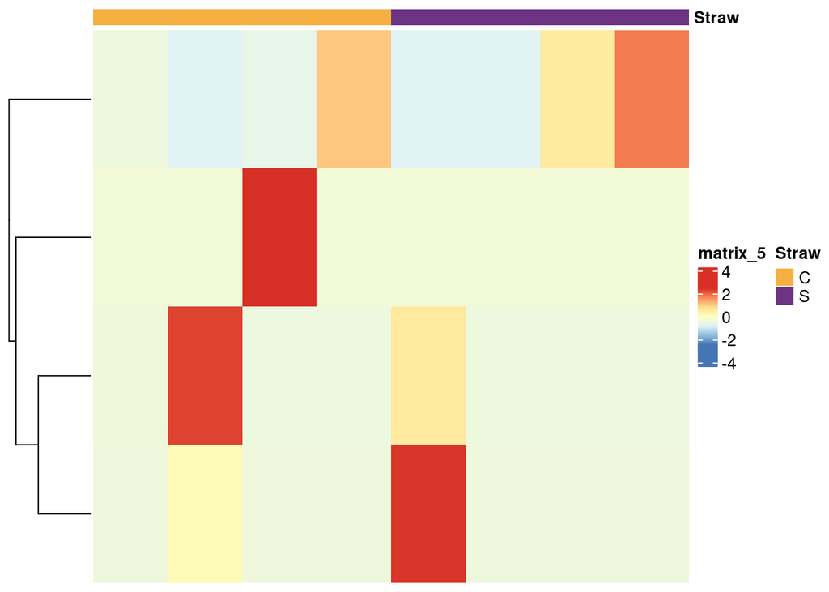

```r
#tmm_mat <- read.table("SeqCap_gene.TMM.EXPR.matrix", header = T, row.names = 1, check.names = F)
#sample_meta <-  read.table("All.samples", header = T, check.names = F)
sm_g_t6 <- sample_meta %>%
  filter(Time == "T6") %>%
  filter(Manag == "G") %>%
  arrange(Straw)


gs_t6_egg <- gs_t6 %>%
  filter(!(is.na(enz_class) & (Transcript %in% silva_hits$V1))) %>%
  filter(!is.na(cog_lev1))
gs_t6_tmm_egg <- tmm_mat[gs_t6_egg$Transcript, (colnames(tmm_mat) %in% sm_g_t6$Samples)]

gs_t6_tmm_egg_cog_lev2 <- gs_t6_tmm_egg %>%
  rownames_to_column(var = "Transcript") %>%
  gather(Sample_ID, count, -Transcript) %>%
  left_join(gs_t6_egg, by = "Transcript") %>%
  group_by(Sample_ID, cog_lev2) %>%
  summarise(sum_count = sum(count)) %>%
  spread(Sample_ID, sum_count)
temp <- gs_t6_tmm_egg_cog_lev2$cog_lev2
gs_t6_tmm_egg_cog_lev2$cog_lev2 <- NULL
row.names(gs_t6_tmm_egg_cog_lev2) <- temp

my_colour = list(
     Straw = c(C = "#F5B041", S = "#6C3483")
)

pheatmap(gs_t6_tmm_egg_cog_lev2[!(rowSums(gs_t6_tmm_egg_cog_lev2)== 0), ], border_color=NA, annotation_col=sm_g_t6[,c("Straw"),drop=F],annotation_legend=T, scale = "row", annotation_colors = my_colour, show_colnames = F, cluster_cols = F)
```

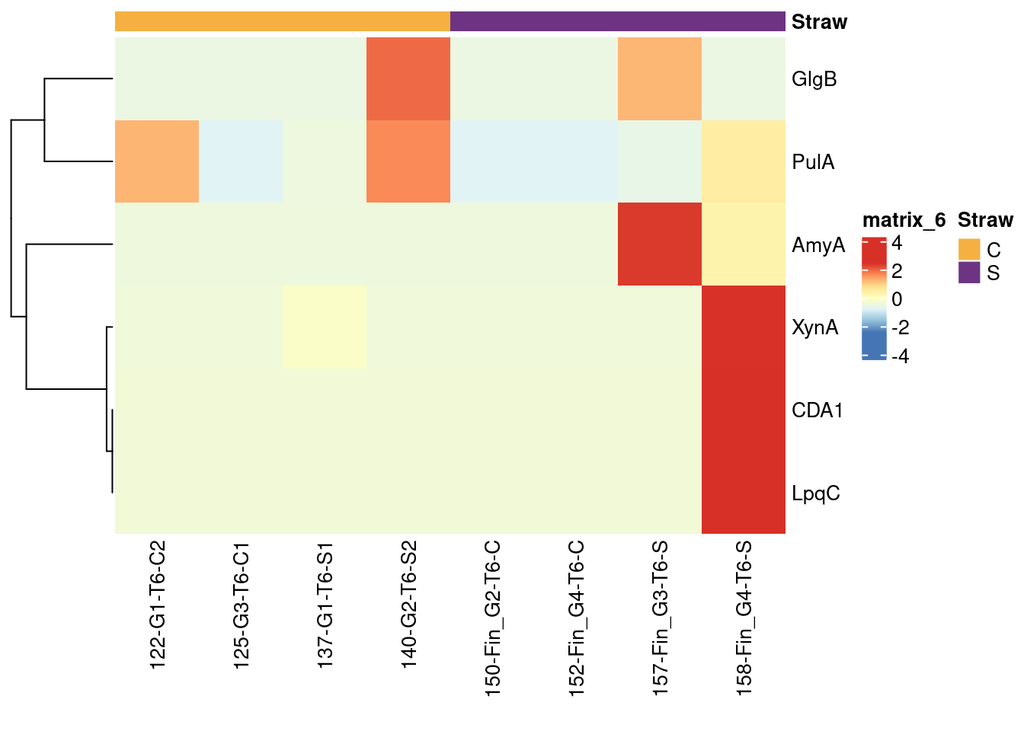

```r
gs_t6_tmm_egg_cog_enz <- gs_t6_tmm_egg %>%
  rownames_to_column(var = "Transcript") %>%
  gather(Sample_ID, count, -Transcript) %>%
  left_join(gs_t6_egg, by = "Transcript") %>%
  filter(cog_lev2 == "Carbohydrate transport and metabolism") %>%
  group_by(Sample_ID, cog_enzid) %>%
  summarise(sum_count = sum(count)) %>%
  spread(Sample_ID, sum_count)

temp <- gs_t6_tmm_egg_cog_enz$cog_enzid
gs_t6_tmm_egg_cog_enz$cog_enzid <- NULL
row.names(gs_t6_tmm_egg_cog_enz) <- temp

my_colour = list(
     Straw = c(C = "#F5B041", S = "#6C3483")
)

pheatmap(gs_t6_tmm_egg_cog_enz, border_color=NA, annotation_col=sm_g_t6[,c("Straw"),drop=F],annotation_legend=T, scale = "row", annotation_colors = my_colour, show_colnames = T, cluster_cols = F)
```

## 1.5 Taxonomy in Straw at different times

Here I try to make the taxonomy plot by combining the taxonomies that are significantly different in the 3 time points while comparing straw samples to the control!

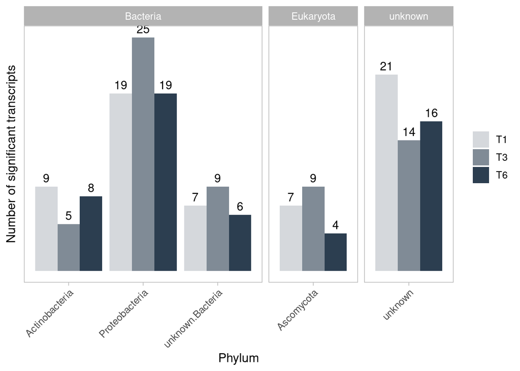

```r
gs_t1_taxa <- gs_t1 %>%
  filter(!(is.na(enz_class) & (Transcript %in% silva_hits$V1))) %>%
  filter(condition == "Straw") %>%
  group_by(Kingdom, Phylum) %>%
  filter(!is.na(Phylum)) %>%
  summarise(num_sig= n())
gs_t1_taxa$time <- "T1"

gs_t3_taxa <- gs_t3 %>%
  filter(!(is.na(enz_class) & (Transcript %in% silva_hits$V1))) %>%
  filter(condition == "Straw") %>%
  group_by(Kingdom, Phylum) %>%
  filter(!is.na(Phylum)) %>%
  summarise(num_sig= n())
gs_t3_taxa$time <- "T3"

gs_t6_taxa <- gs_t6 %>%
  filter(!(is.na(enz_class) & (Transcript %in% silva_hits$V1))) %>%
  filter(condition == "Straw") %>%
  group_by(Kingdom, Phylum) %>%
  filter(!is.na(Phylum)) %>%
  summarise(num_sig= n())
gs_t6_taxa$time <- "T6"

gs_taxa_allT <- rbind(gs_t1_taxa, gs_t3_taxa, gs_t6_taxa)
gs_taxa_allT$Kingdom <- factor(gs_taxa_allT$Kingdom, levels = c("Bacteria", "Eukaryota", "unknown"))

rem_phyla <- gs_taxa_allT %>%
  group_by(Phylum) %>%
  summarise(tot_sig= sum(num_sig)) %>%
  filter(tot_sig > 5)

gs_taxa_allT <- gs_taxa_allT %>%
  filter(Phylum %in% rem_phyla$Phylum)


ggplot(gs_taxa_allT) +
  geom_bar(aes(x = Phylum, y = num_sig, fill = time),
           stat = "identity", position = position_dodge(preserve = "single")) +
  geom_text(aes(Phylum, num_sig, label=num_sig, group = time),
            vjust = -0.5, size=4, position = position_dodge(width = .9)) +
  theme_light(base_size = 12) +
  ylab("Number of significant transcripts") +
  theme(axis.text.x = element_text(angle = 45, hjust = 1), panel.grid.major = element_blank(), panel.grid.minor = element_blank(),
        axis.text.y = element_blank(), axis.ticks.y = element_blank(), legend.title = element_blank()) +
  facet_grid(cols = vars(Kingdom), space = "free", scales = "free") +
  scale_fill_manual(values = c("#D5D8DC", "#808B96", "#2C3E50"))
```

### 1.5.1 Important Phyla

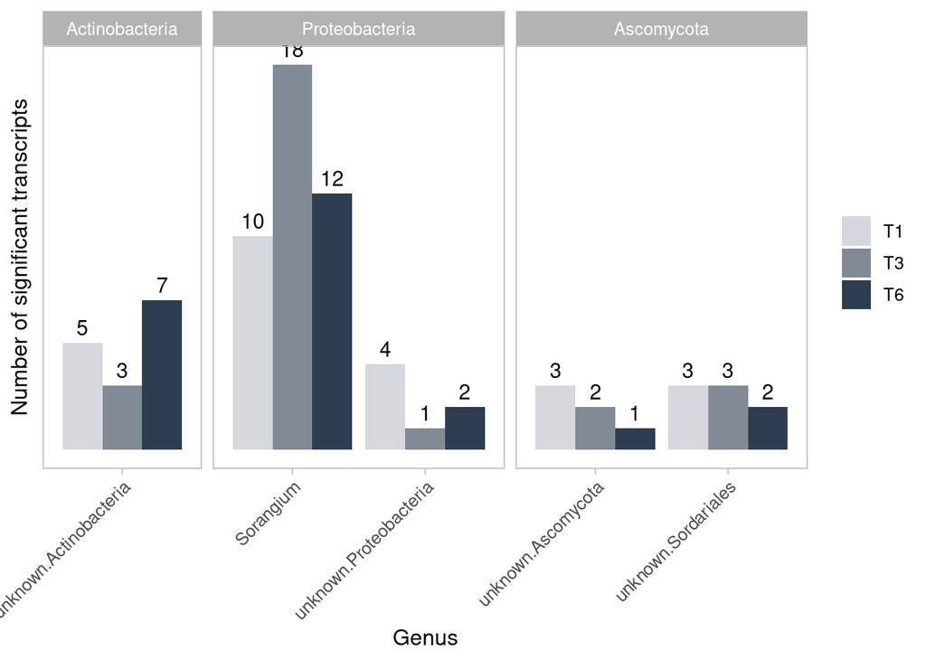

```r
gs_t1_taxa <- gs_t1 %>%
  filter(!(is.na(enz_class) & (Transcript %in% silva_hits$V1))) %>%
  filter(condition == "Straw") %>%
  group_by(Phylum, Genus) %>%
  filter(!is.na(Phylum)) %>%
  summarise(num_sig= n())
gs_t1_taxa$time <- "T1"

gs_t3_taxa <- gs_t3 %>%
  filter(!(is.na(enz_class) & (Transcript %in% silva_hits$V1))) %>%
  filter(condition == "Straw") %>%
  group_by(Phylum, Genus) %>%
  filter(!is.na(Phylum)) %>%
  summarise(num_sig= n())
gs_t3_taxa$time <- "T3"

gs_t6_taxa <- gs_t6 %>%
  filter(!(is.na(enz_class) & (Transcript %in% silva_hits$V1))) %>%
  filter(condition == "Straw") %>%
  group_by(Phylum, Genus) %>%
  filter(!is.na(Phylum)) %>%
  summarise(num_sig= n())
gs_t6_taxa$time <- "T6"

gs_taxa_allT <- rbind(gs_t1_taxa, gs_t3_taxa, gs_t6_taxa)

keep_phyla <- c("Actinobacteria", "Proteobacteria", "Ascomycota")

rem_phyla <- gs_taxa_allT %>%
  filter(Phylum %in% keep_phyla) %>%
  group_by(Genus) %>%
  summarise(tot_sig= sum(num_sig)) %>%
  filter(tot_sig > 5)

gs_taxa_allT <- gs_taxa_allT %>%
  filter(Phylum %in% keep_phyla) %>%
  filter(Genus %in% rem_phyla$Genus)
gs_taxa_allT$Phylum <- factor(gs_taxa_allT$Phylum, levels = c("Actinobacteria", "Proteobacteria", "Ascomycota"))

ggplot(gs_taxa_allT) +
  geom_bar(aes(x = Genus, y = num_sig, fill = time),
           stat = "identity", position = position_dodge(preserve = "single")) +
  geom_text(aes(Genus, num_sig, label=num_sig, group = time),
            vjust = -0.5, size=4, position = position_dodge(width = .9)) +
  theme_light(base_size = 12) +
  ylab("Number of significant transcripts") +
  theme(axis.text.x = element_text(angle = 45, hjust = 1), panel.grid.major = element_blank(), panel.grid.minor = element_blank(),
        axis.text.y = element_blank(), axis.ticks.y = element_blank(), legend.title = element_blank()) +
  facet_grid(cols = vars(Phylum), space = "free", scales = "free") +
  scale_fill_manual(values = c("#D5D8DC", "#808B96", "#2C3E50"))
```

## 1.6 Change in time (Mainly straw T6 vs T1)

Since this is the most interesting part, let us just focus on this!

### 1.6.1 In T6

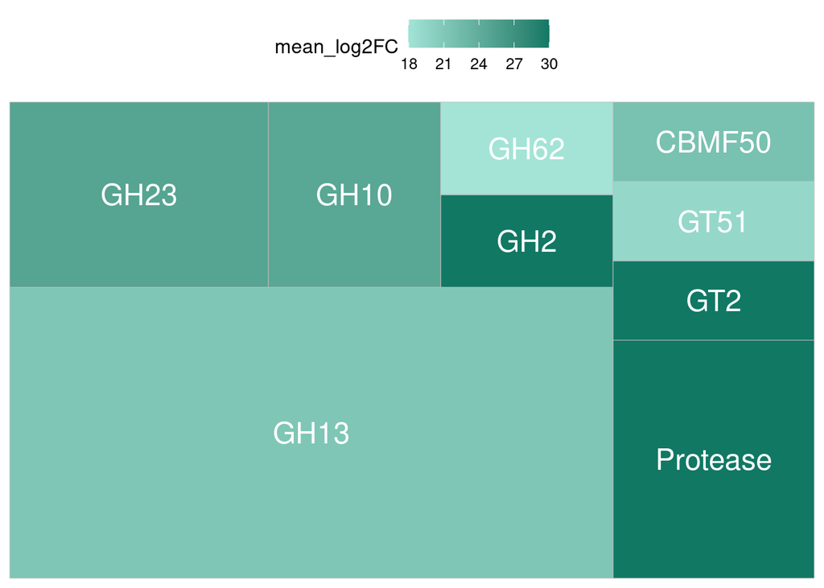

```r
gs_t6vt1_tdb <- gs_t6vt1_all %>%
  filter(!(is.na(enz_class) & (Transcript %in% silva_hits$V1))) %>%
  filter(condition == "T6") %>%
  group_by(enz_class, enz_family) %>%
  summarise(num_sig= n(), mean_log2FC = mean(abs(log2FoldChange))) %>%
  filter(!is.na(enz_class)) %>%
  arrange(desc(num_sig))

ggplot(data = gs_t6vt1_tdb, aes(fill = mean_log2FC, area = num_sig, label= enz_family, subgroup=enz_class)) +
  geom_treemap() +
  geom_treemap_text(colour ="white", place = "centre") +
  theme_pubclean(base_size = 12) +
  scale_fill_gradient(low = "#A3E4D7", high = "#117864")
```

There were `62` transcripts in total that were significantly abundant t6 compared to t1 in straw samples! Out of which `24` had matches to the TDB. The top CAZy families are listed below:

```r
#gs_all %>%
#  filter(condition == "Straw") %>%
#  dim()
#sum(gs_all_tdb$num_sig)
kable(head(gs_t6vt1_tdb, 10))
```

| enz_class | enz_family | num_sig | mean_log2FC |
| --- | --- | --- | --- |
| GH | GH13 | 11 | 21.24305 |
| GH | GH23 | 3 | 24.94255 |
| Protease | Protease | 3 | 30.00000 |
| GH | GH10 | 2 | 24.65778 |
| CBMF | CBMF50 | 1 | 21.79268 |
| GH | GH2 | 1 | 30.00000 |
| GH | GH62 | 1 | 17.97309 |
| GT | GT2 | 1 | 30.00000 |
| GT | GT51 | 1 | 19.28143 |

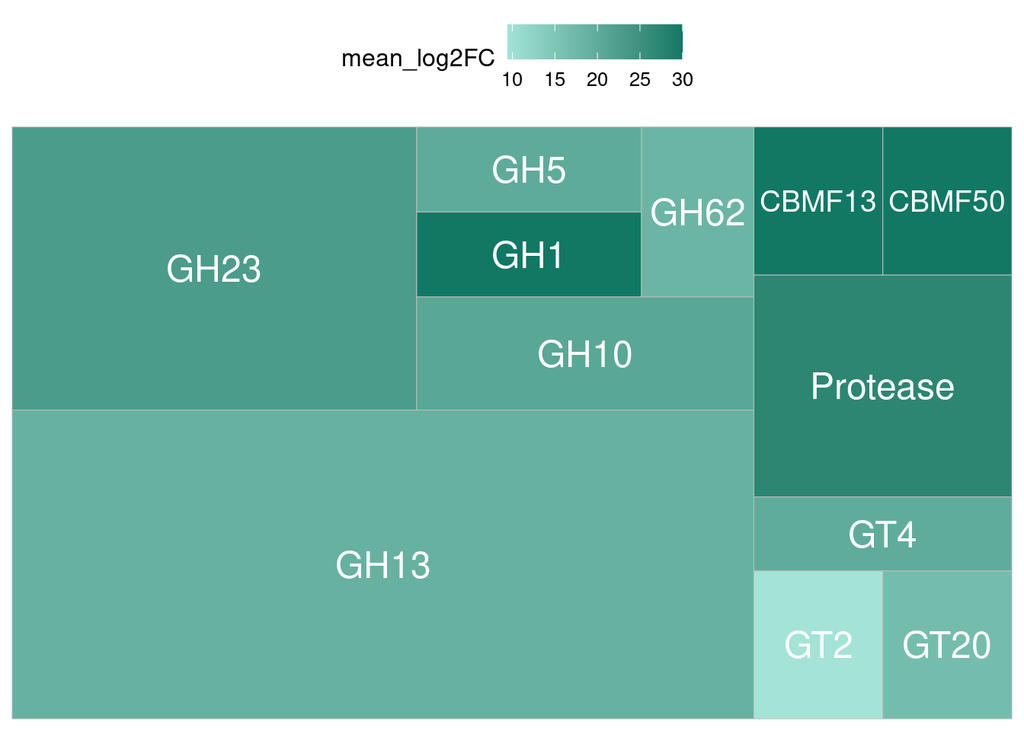

```r
gs_t6vt1_tdb <- gs_t6vt1_all %>%
  filter(!(is.na(enz_class) & (Transcript %in% silva_hits$V1))) %>%
  filter(condition == "T1") %>%
  group_by(enz_class, enz_family) %>%
  summarise(num_sig= n(), mean_log2FC = mean(abs(log2FoldChange))) %>%
  filter(!is.na(enz_class)) %>%
  arrange(desc(num_sig))

ggplot(data = gs_t6vt1_tdb, aes(fill = mean_log2FC, area = num_sig, label= enz_family, subgroup=enz_class)) +
  geom_treemap() +
  geom_treemap_text(colour ="white", place = "centre") +
  theme_pubclean(base_size = 12) +
  scale_fill_gradient(low = "#A3E4D7", high = "#117864")
```

```r
#gs_all %>%
#  filter(condition == "Straw") %>%
#  dim()
#sum(gs_all_tdb$num_sig)
kable(head(gs_t6vt1_tdb, 10))
```

| enz_class | enz_family | num_sig | mean_log2FC |
| --- | --- | --- | --- |
| GH | GH13 | 12 | 18.947248 |
| GH | GH23 | 6 | 22.940450 |
| Protease | Protease | 3 | 27.247444 |
| GH | GH10 | 2 | 20.849476 |
| CBMF | CBMF13 | 1 | 29.973728 |
| CBMF | CBMF50 | 1 | 30.000000 |
| GH | GH1 | 1 | 30.000000 |
| GH | GH5 | 1 | 20.043240 |
| GH | GH62 | 1 | 18.073890 |
| GT | GT2 | 1 | 9.433998 |

```r
de_grass_overview <- ggplot(data = ovr_nsig_data) +
  geom_bar(aes(x = test, y = log10(num_sig), fill = condition),
           position = "dodge",stat = "identity") +
  geom_text(aes(test, log10(num_sig), label=num_sig, group = condition),
            vjust = 1.5, size=4, position = position_dodge(width = .9)) +
  facet_wrap(~Main_test, scales = "free_x") +
  scale_fill_manual(values = c("#F5B041", "#6C3483", "#D5D8DC", "#808B96", "#2C3E50")) +
  ylab("Number of DE transcripts [log10]") +
  theme_pubclean(base_size = 12) +
  theme(axis.text.y = element_blank(), axis.ticks.y = element_blank(), axis.title = element_blank()) + labs(fill = "") + labs(tag="b)") +
  scale_y_continuous(limits = c(0, 2.6))
```